# Lab 4

P-Hackers

9/22/2019

## Over-Arching Goals

### 1) Analysis of premature births

A premature birth is defined as one that occurs before a gestational age of 270 days. We want to see the linear corilation between premature births from mothers that smoked durning their pregnancy vs. the mothers that did not smoke during their pregnancy.

### 2) Analysis of birth weights at gestational ages

To test the Surgeon General’s assertion that newborns of mothers who smoke have lower birth weights at every gestational age (number of days into the pregnancy when the child is born), we want to create graphs to visualize the linear relationship between smoking mothers and the babies weight at the gestational age.

## Team Hypothesis

### Question 1

We believe that there will be a strong positive corilation between premature births and mothers smoking while pregnant.

### Question 2

There will be a positive correlation between the length of gestation and birth weight. Because the baby develops during gestation, it follows that a longer period of gestation would result in higher birth weight. We also predict that the children of smoking mothers will weigh less than children of non-smoking mothers.

## Why Important

### Question 1

Determining the effect smoking has on the rate of pre-term birth is of vital importance to new mothers. If smoking harms the health of a newborn child, the public must be informed of these risks so that they may take the necessary steps to protect themselves and their families.

## More Detailed Why Important

### Question 1

If it’s found that smoking harms pregnant women and their babies, it’s reasonable to assume that expecting mothers would stop, or severely limit their smoking. This would deal a catastrophic blow to cigarette manufacturers. Additionally, it would provide further information as to why babies are born prematurely and could open up new avenues of inquiry as to the effects of smoking on pregnancy and birth.

## Additional Team Study

### Smokers vs. NonSmokers

**Threats to the Valididty of the Experiment:**

It’s imperative to note each of the variables taken into consideration during the experiment. While more variables result in less error, it’s nearly impossible to consider all of the threats. Note that the variables considered while running the numbers are as follows: ID, birthday, gestation length, birth weight, mother’s/father’s race, mother’s/father’s age, mother’s/father’s education level, mother’s/father’s pre-pregnancy weight, marital status of the mother, family income, mother’s smoking, how long the mother has been smoking/ how long since she quit smoking, the number of cigarettes the mother smokes per-day, and if the baby was born prematurely.

#### Here are some graphs showing the variables that we thought are simular between smoking mothers and non-smoking mothers:

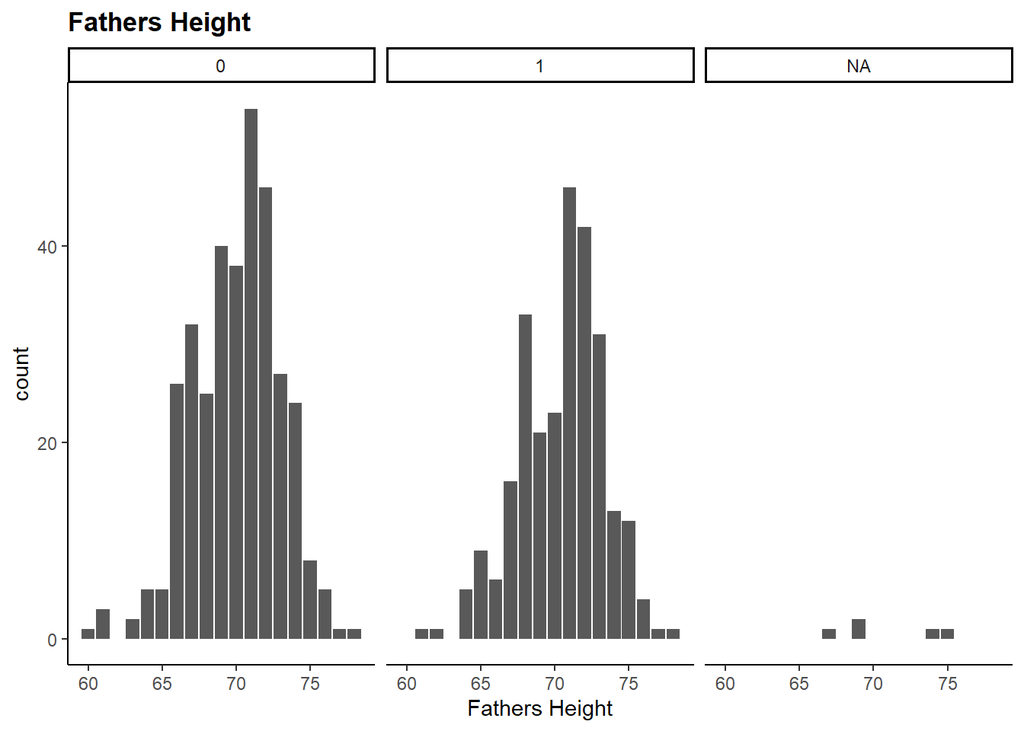

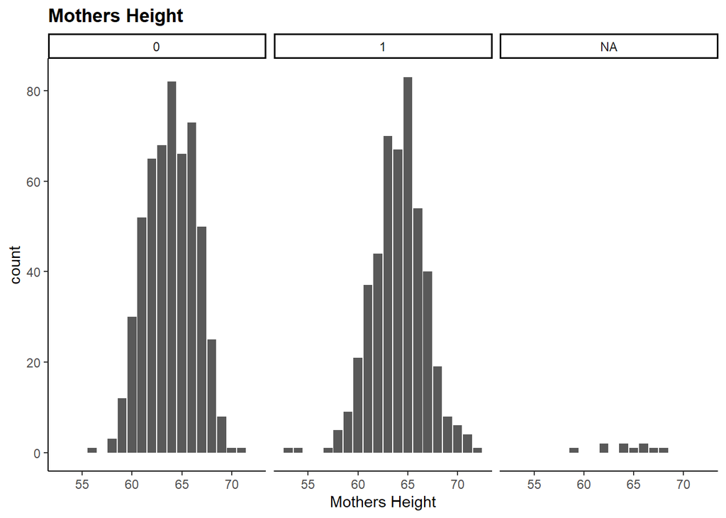

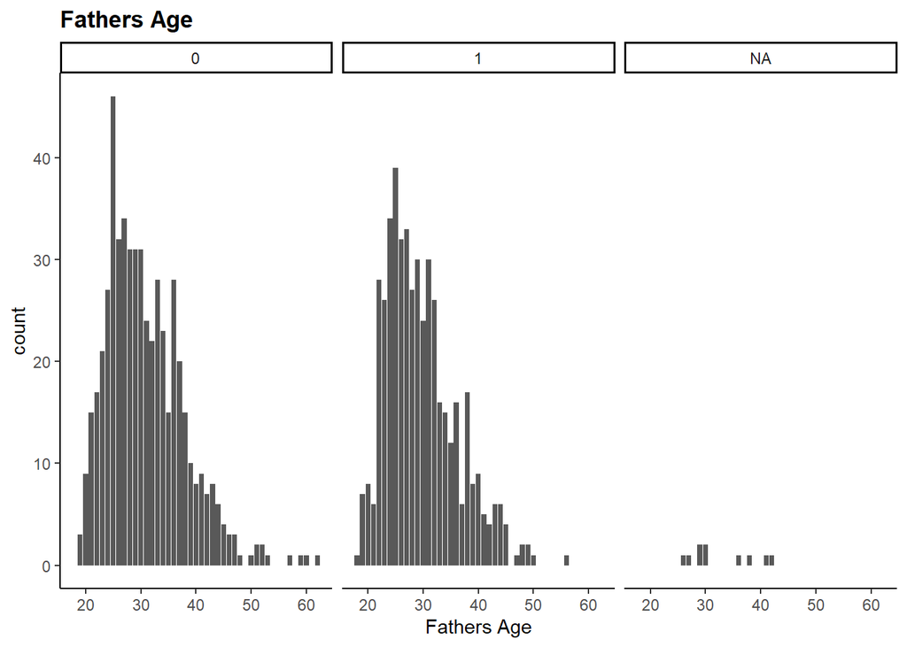

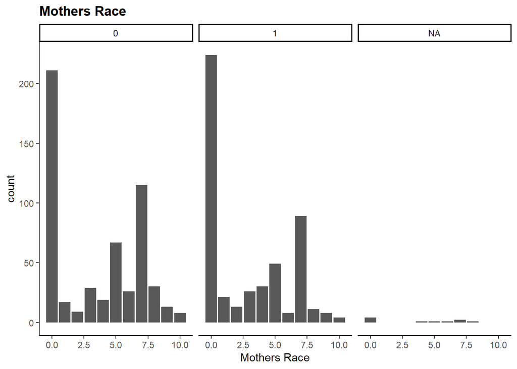

[figure not shown]

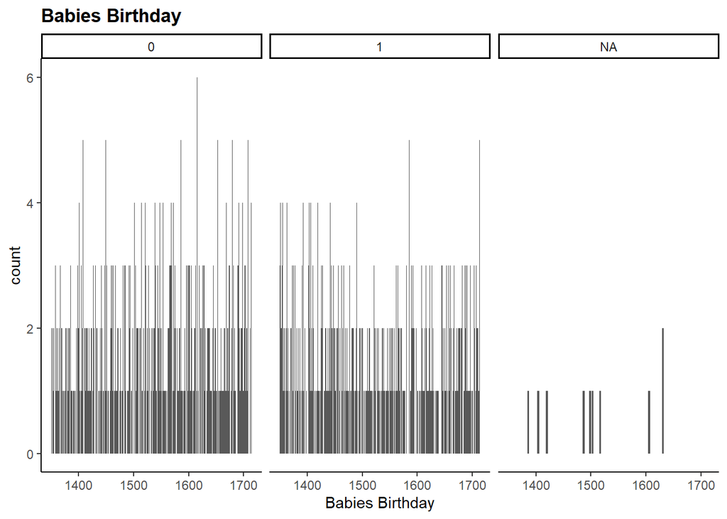

#### Here are some graphs showing the variables that we thought are noticably different between smoking mothers and non-smoking mothers:

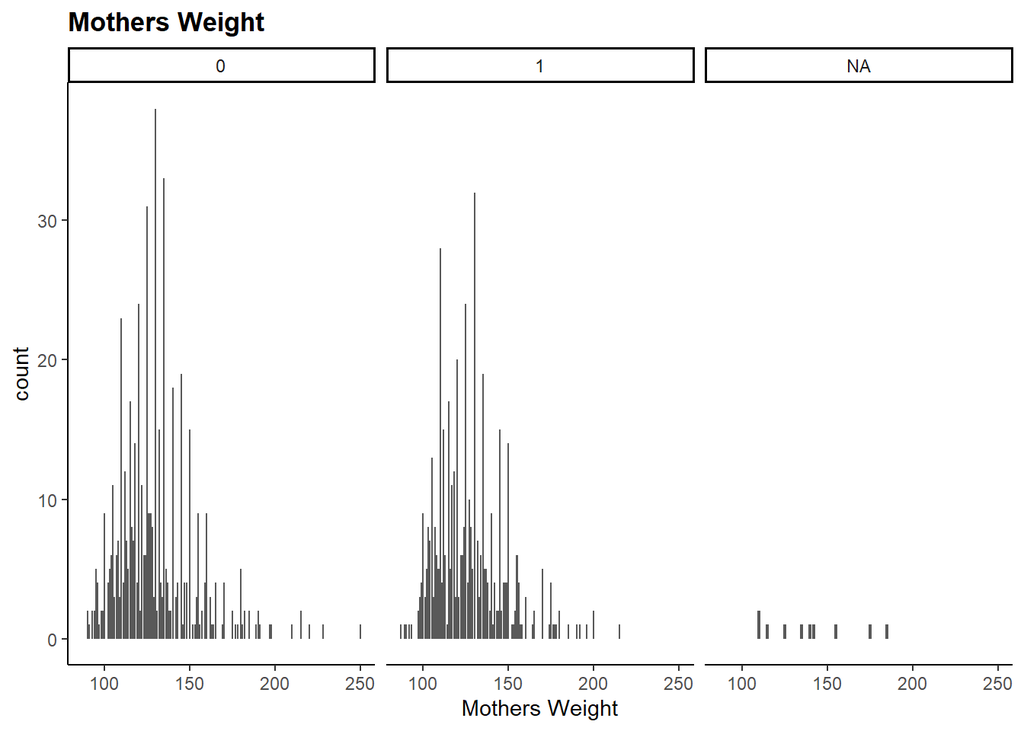

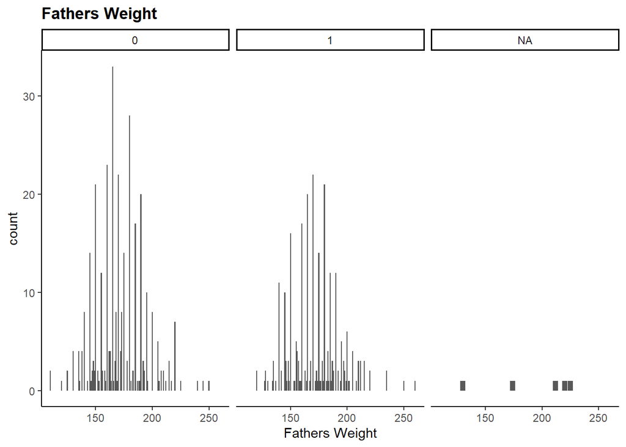

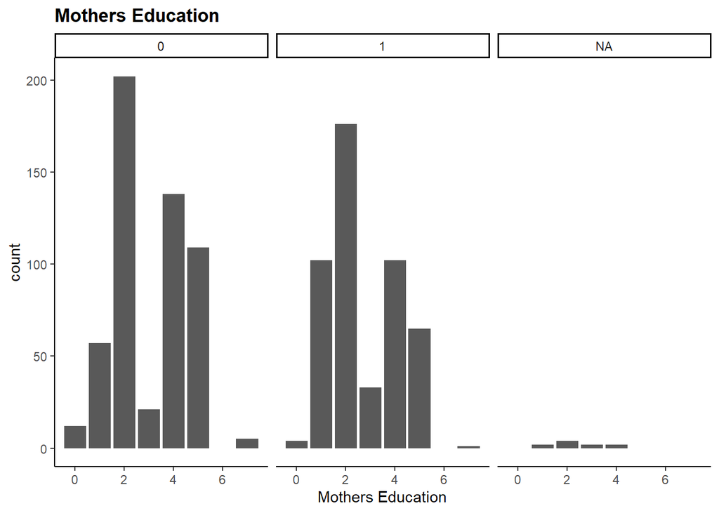

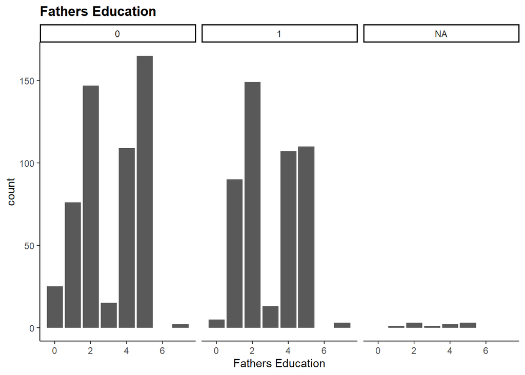

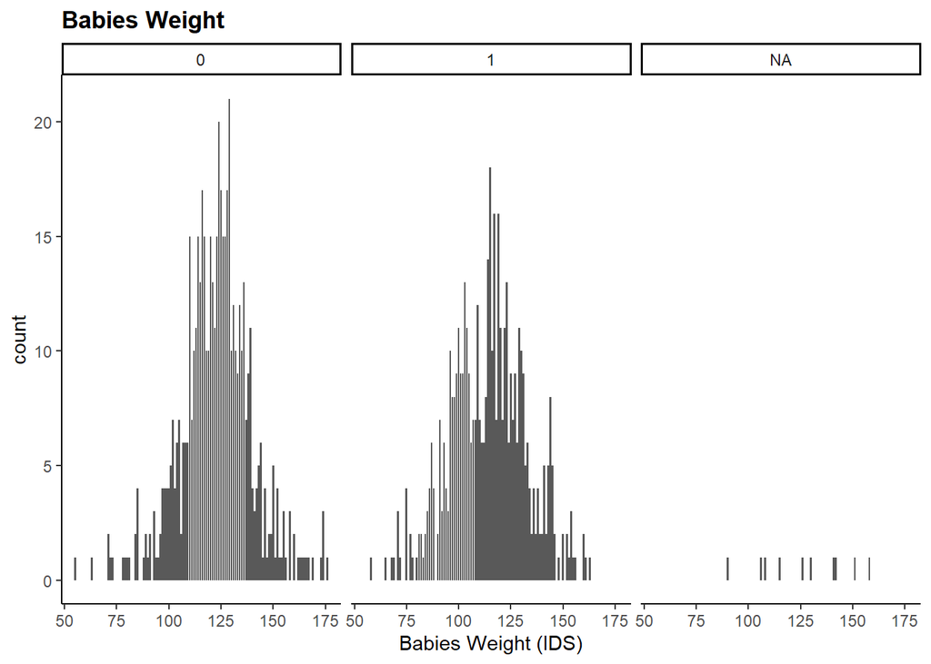

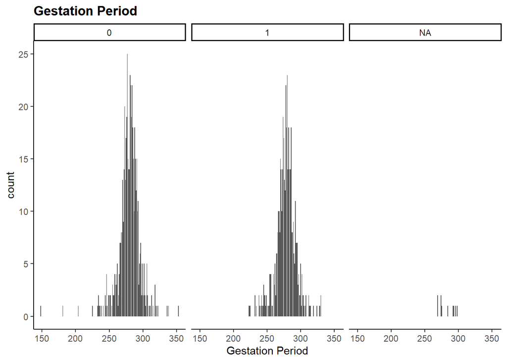

### Plot for Hypothesis 1

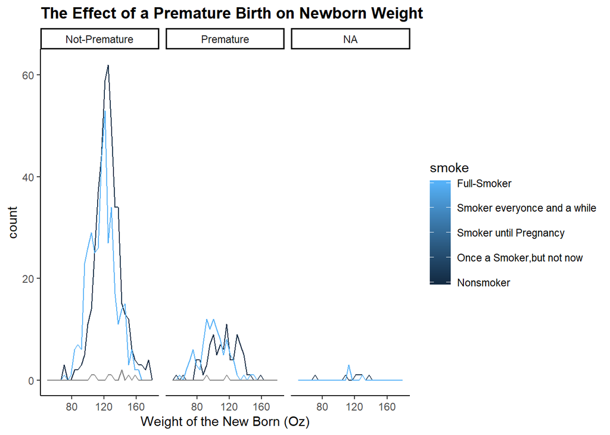

### Plot for Hypothesis 2

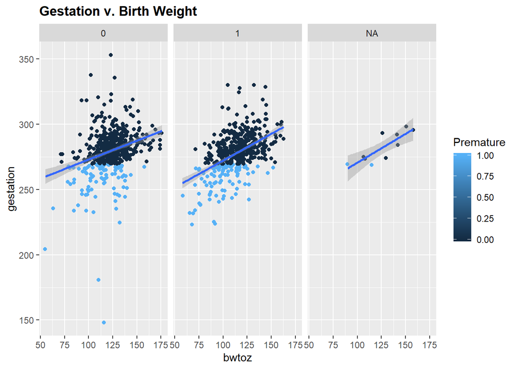

```
##
## Call:
## lm(formula = gestation ~ bwtoz, data = babies)
##
## Coefficients:
## (Intercept)        bwtoz
##    238.2283       0.3422
```

## Individual Studies

### Julia Foley

#### Question

What is the correlation between a mother’s pregnant weight and a baby’s birth weight? Do babies with mothers who smoke have a higher or lower birth weight? Are babies whose mothers smoke more likely to be premature than babies whose mothers don’t smoke?

#### Hypothesis

I believe that there will be a positive correlation between birth weight and mother’s pregnant weight. Additionally, I believe that Premature babies will have a lower birth weight than babies who are not premature. Lastly, I believe that in the premature section, there will be more babies whose mothers smoke than babies whose mothers did not smoke.

#### Birth Weight v. Mother’s Weight in Relation to Smoking

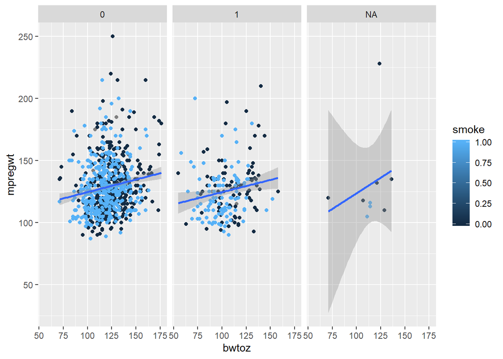

```
##
## Call:
## lm(formula = mpregwt ~ bwtoz, data = babies)
##
## Coefficients:
## (Intercept)        bwtoz
##    104.2397       0.2044
```

### Declan Franklin

#### Question:

Does Income effect weather the mother smokes or not?

#### Hypothesis:

If both parents have a higher income, the mother is less likely to smoke during pregnancy.

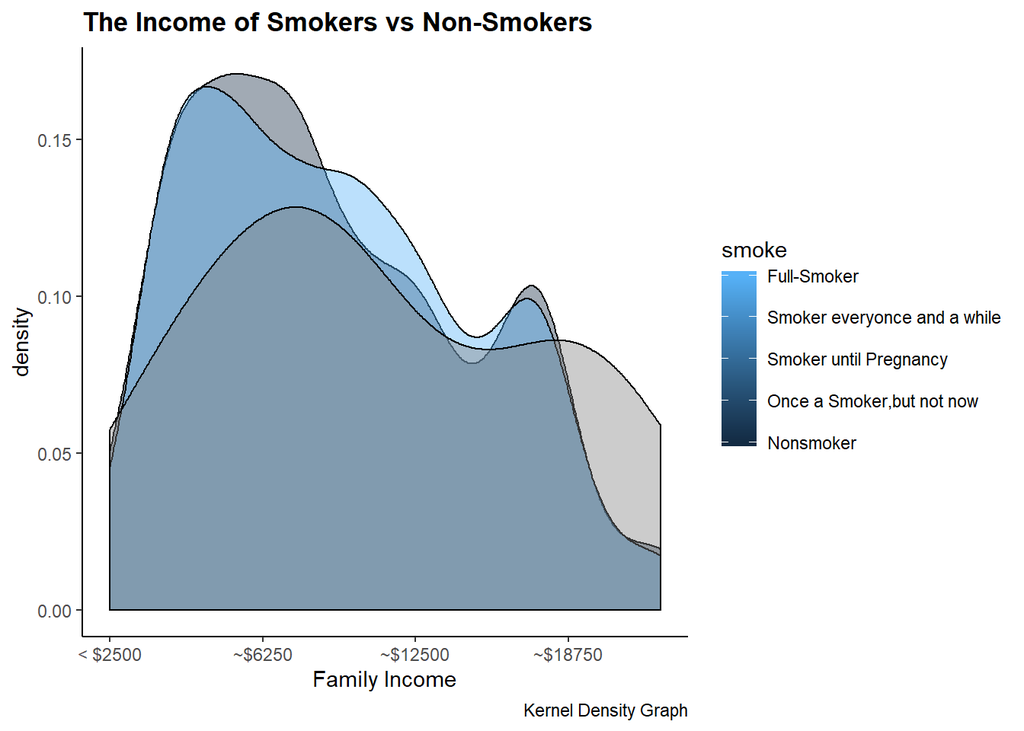

#### Findings:

I found that most new families between $2500 - $7000. I also found that the non-smokers make more money than the smokers. This info could give insight to our team’s data by giving us insight on what the families can bring to the table while pregnant.

### Nisia Pinto

**Question:**

Mother Education Vs Dad Education and Parity: Do couples with higher education tend to have less kids than the ones with lower education?**

**Hypothesis:**

Couples with higher educational levels have less kids than the ones with lower educational levels.

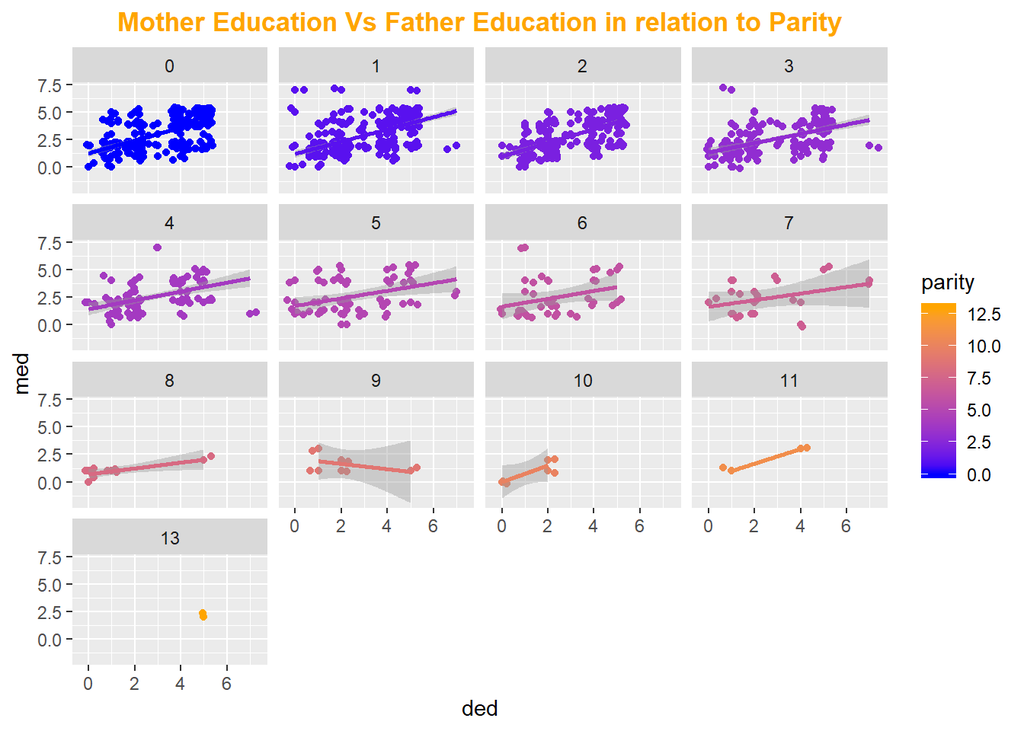

**Findings:**

Correlations: **Med vs Ded:** 0.5992664 **Med vs Parity** : -0.1760948 **Ded vs Parity:** -0.1312375

The mather and father’s education are positively correlated. However, parity is negatively correlated to both of them. I was able to answer my question and confirm my hypothesis, people with higher education have less babies than less educated people. This can be due to the addition of other different factors:college tuitions, retirement money, health care, or salary. In addition, we can see that the positive correlations are moderate and the negative are weak.

### Question:

1. Given the dataset we have, is there enough information to make a conclusion as to whether smoking is the main factor in decreased birth weights? Or could lower birthweights be explained better by a combination of factors including smoking as well as the height and weight of the mother and father?
2. Are there really that many more premature births associated with smokers as opposed to non-smokers? What else could cause a premature birth?

#### Hypothesis

There will be an insignificant difference in the number of premature births attributed to smoking mothers and those attributed to non-smoking mothers.

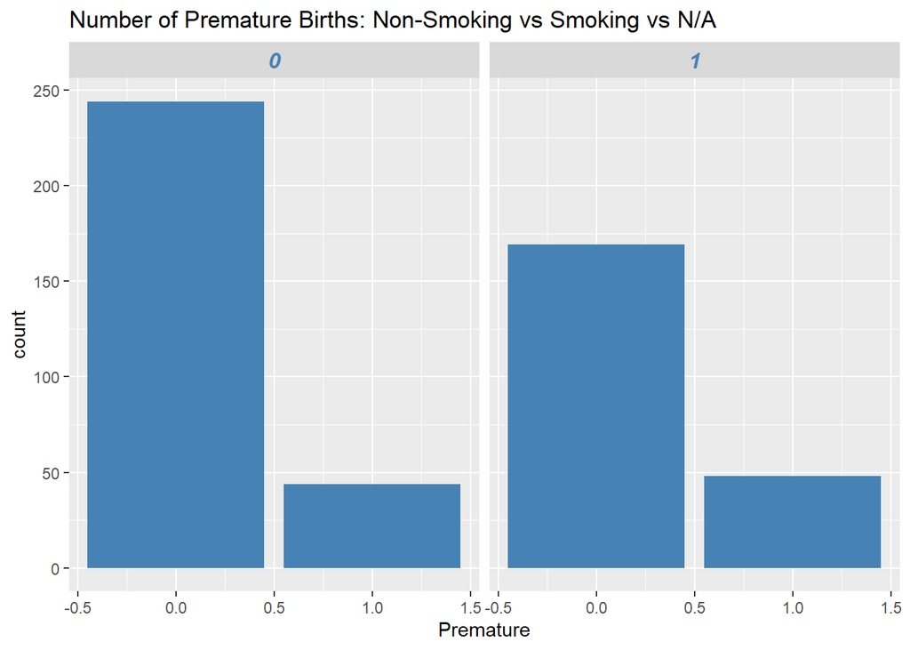

## What each Member did

### Julia Foley

#### Individual

I created a plot using ggplot, geom_point, geom_smooth, lm, facet_wrap, and color = smoke. I also used lm to find the equation of the line. This helped me to compare the relationship between mother’s pregnant weight, birth weight, premature, and smoking. Additionally, I made a question and a hypothesis, and I reported my findings.

#### Team

I created the document, I wrote the hypothesis and the conclusion for question 2. I also helped out with plot 2.

### Declan Franklin

#### Team

For the team: I created all the plots of potentially similar and different variables, I answered the Validity question, I formatted the HTML for aesthetic purposes, and I did the final review of everyone’s Code to make sure it ran correctly and neatly.

### Andres Acevedo

#### Individual

I created a multitude of plots relating variables in the dataset ‘babies’. I noticed there were very few variables that were even moderately correlated save for gestation vs baby weight. I used a geom_bar() object to count the number of premature births for smoking mothers as opposed to non-smoking mothers. I used a facet_wrap() to compare the smokers to the non-smokers. I applied a theme to the labels across the top of the plot. I filled in the bars of the graph with the color ‘steelblue’ and I applied a title to the graph using ggtitle().

#### Team

I went through all of the team language in our Markdown file and touched it up so that it would be more suitable to a formal setting like a meeting with a client. I formalized the language and corrected any mistakes or typos that I found.